# Development of strategies to identify and expand asset customers

#### Note:

We can use pruning for the decision tree models as well. We can use cost complexity pruning to avoid overfitting the decision tree.

```python
clasf = DecisionTreeClassifier(random_state=1, class_weight={0: 0.10, 1: 0.9})
path = clasf.cost_complexity_pruning_path(X_train, y_train)
ccp_alphas, impurities = path.ccp_alphas, path.impurities
```

```python
pd.DataFrame(path)
```

|  | ccp_alphas | impurities |
| --- | --- | --- |
| 0 | 0.000000e+00 | -7.456201e-16 |
| 1 | 1.389864e-19 | -7.454811e-16 |
| 2 | 2.918714e-19 | -7.451893e-16 |
| 3 | 4.725536e-19 | -7.447167e-16 |
| 4 | 8.339181e-19 | -7.438828e-16 |
| 5 | 1.056296e-18 | -7.428265e-16 |
| 6 | 1.876316e-18 | -7.409502e-16 |
| 7 | 1.876316e-18 | -7.390739e-16 |
| 8 | 1.876316e-18 | -7.371975e-16 |
| 9 | 2.126491e-18 | -7.350710e-16 |
| 10 | 2.501754e-18 | -7.325693e-16 |
| 11 | 2.710234e-18 | -7.298591e-16 |
| 12 | 2.326632e-17 | -7.065927e-16 |
| 13 | 4.447563e-17 | -6.621171e-16 |
| 14 | 2.039486e-16 | -4.581685e-16 |
| 15 | 8.259125e-15 | 7.800957e-15 |
| 16 | 1.229116e-04 | 2.458233e-04 |
| 17 | 1.229116e-04 | 4.916466e-04 |
| 18 | 1.234729e-04 | 7.385923e-04 |
| 19 | 1.244198e-04 | 9.874318e-04 |
| 20 | 1.827065e-04 | 1.718258e-03 |
| 21 | 2.253380e-04 | 1.943596e-03 |
| 22 | 2.299367e-04 | 2.863343e-03 |
| 23 | 2.331083e-04 | 3.329559e-03 |
| 24 | 2.370439e-04 | 3.566603e-03 |
| 25 | 2.370439e-04 | 3.803647e-03 |
| 26 | 2.402716e-04 | 4.043919e-03 |
| 27 | 2.414877e-04 | 5.251357e-03 |
| 28 | 2.458233e-04 | 5.497181e-03 |
| 29 | 2.795637e-04 | 6.894999e-03 |
| 30 | 3.380070e-04 | 7.233006e-03 |
| 31 | 3.386663e-04 | 8.249005e-03 |
| 32 | 4.060596e-04 | 8.655065e-03 |
| 33 | 4.097055e-04 | 9.474476e-03 |
| 34 | 4.495660e-04 | 9.924042e-03 |
| 35 | 4.572799e-04 | 1.083860e-02 |
| 36 | 4.678210e-04 | 1.224206e-02 |
| 37 | 6.438229e-04 | 1.288589e-02 |
| 38 | 7.809172e-04 | 1.366680e-02 |
| 39 | 8.481063e-04 | 1.621112e-02 |
| 40 | 8.561571e-04 | 1.877959e-02 |
| 41 | 8.722762e-04 | 1.965187e-02 |
| 42 | 1.070063e-03 | 2.072193e-02 |
| 43 | 1.083539e-03 | 2.288901e-02 |
| 44 | 1.173310e-03 | 2.640894e-02 |
| 45 | 1.254588e-03 | 2.766353e-02 |
| 46 | 1.331543e-03 | 2.899507e-02 |
| 47 | 1.539976e-03 | 3.207503e-02 |
| 48 | 1.684056e-03 | 3.375908e-02 |
| 49 | 1.732071e-03 | 3.549115e-02 |
| 50 | 2.882478e-03 | 3.837363e-02 |
| 51 | 3.168402e-03 | 4.154203e-02 |
| 52 | 3.788425e-03 | 4.911888e-02 |
| 53 | 7.195003e-03 | 5.631389e-02 |
| 54 | 8.534089e-03 | 7.338206e-02 |
| 55 | 2.124227e-02 | 9.462433e-02 |
| 56 | 5.785689e-02 | 2.103381e-01 |
| 57 | 2.895083e-01 | 4.998464e-01 |

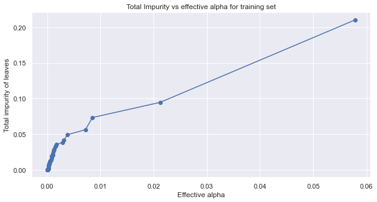

```python
# Visualization of the above column
fig, ax = plt.subplots(figsize=(10, 5))
ax.plot(ccp_alphas[:-1], impurities[:-1], marker="o")
ax.set_xlabel("Effective alpha")
ax.set_ylabel("Total impurity of leaves")
ax.set_title("Total Impurity vs effective alpha for training set")
plt.show()
```

```python
clfs = []
for ccp_alpha in ccp_alphas:
    clf = DecisionTreeClassifier(
        random_state=1, ccp_alpha=ccp_alpha, class_weight={0: 0.1, 1: 0.9}
    )
    clf.fit(X_train, y_train)
    clfs.append(clf)
print(
    "Number of nodes in the last tree is: {} with ccp_alpha: {}".format(
        clfs[-1].tree_.node_count, ccp_alphas[-1]
    )
)
```

```
Number of nodes in the last tree is: 1 with ccp_alpha: 0.2895083028257237
```

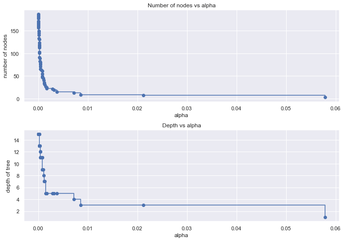

```python
clfs = clfs[:-1]
ccp_alphas = ccp_alphas[:-1]

node_counts = [clf.tree_.node_count for clf in clfs]
depth = [clf.tree_.max_depth for clf in clfs]
fig, ax = plt.subplots(2, 1, figsize=(10, 7))
ax[0].plot(ccp_alphas, node_counts, marker="o", drawstyle="steps-post")
ax[0].set_xlabel("alpha")
ax[0].set_ylabel("number of nodes")
ax[0].set_title("Number of nodes vs alpha")
ax[1].plot(ccp_alphas, depth, marker="o", drawstyle="steps-post")
ax[1].set_xlabel("alpha")
ax[1].set_ylabel("depth of tree")
ax[1].set_title("Depth vs alpha")
fig.tight_layout()
```

```python
recall_train = []
for clf in clfs:
    pred_train = clf.predict(X_train)
    values_train = recall_score(y_train, pred_train)
    recall_train.append(values_train)
```

```python
recall_test = []
for clf in clfs:
    pred_test = clf.predict(X_test)
    values_test = recall_score(y_test, pred_test)
    recall_test.append(values_test)
```

```python
train_scores = [clf.score(X_train, y_train) for clf in clfs]
test_scores = [clf.score(X_test, y_test) for clf in clfs]
```

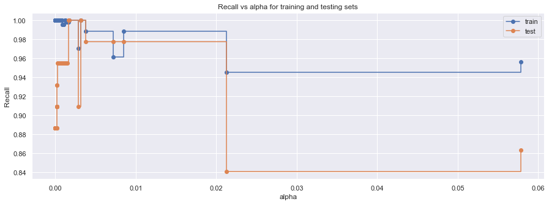

```python
fig, ax = plt.subplots(figsize=(15, 5))
ax.set_xlabel("alpha")
ax.set_ylabel("Recall")
ax.set_title("Recall vs alpha for training and testing sets")
ax.plot(
    ccp_alphas,
    recall_train,
    marker="o",
    label="train",
    drawstyle="steps-post",
)
ax.plot(ccp_alphas, recall_test, marker="o", label="test", drawstyle="steps-post")
ax.legend()
plt.show()
```

#### Observation

```python
# creating the model where we get highest train and test recall
index_best_model = np.argmax(recall_test)
best_model = clfs[index_best_model]
print(best_model)
```

```
DecisionTreeClassifier(ccp_alpha=0.0016840561549870663,
                       class_weight={0: 0.1, 1: 0.9}, random_state=1)
```

```python
best_model.fit(X_train, y_train)
```

```
DecisionTreeClassifier(ccp_alpha=0.0016840561549870663,
                       class_weight={0: 0.1, 1: 0.9}, random_state=1)
```

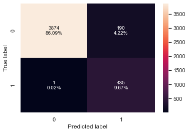

```python
# Generating confusion matrix for training data set for cost complexity decision tree model
confusion_matrix_sklearn(best_model, X_train, y_train)
```

#### Observations

```python
# Generating performance metrics for training data for decision tree with cost complexity pruning
decision_tree_alpha_perf_train = model_performance_classification_sklearn1(
    best_model, X_train, y_train
)
print("Training performance:")
decision_tree_alpha_perf_train
```

```
Training performance:
```

|  | Accuracy | Recall | Precision | F1 |
| --- | --- | --- | --- | --- |
| 0 | 0.957556 | 0.997706 | 0.696 | 0.819981 |

#### Observations

The recall is 99.7%, while precision is 69.6%. The F1 is 81.9%.

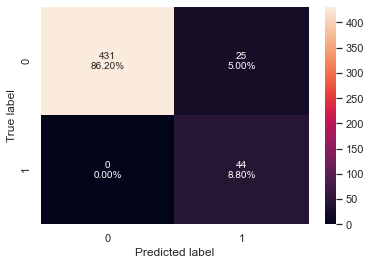

```python
# Generating confusion matrix for testing set for decision tree with cost complexity pruning
confusion_matrix_sklearn(best_model, X_test, y_test)
```

#### Observations

1. The true positives (Predicted label = 1, True label = 1) = 8.8%.
2. The true negatives (Predicted label = 0, True label = 0) = 86.2%
3. False positives = 5% and False negatives = 0%.

```python
# Generating performance metrics for testing data for decision tree with cost complexity pruning
decision_tree_alpha_perf_test = model_performance_classification_sklearn1(
    best_model, X_test, y_test
)
print("Training performance:")
decision_tree_alpha_perf_test
```

```
Training performance:
```

|  | Accuracy | Recall | Precision | F1 |
| --- | --- | --- | --- | --- |
| 0 | 0.95 | 1.0 | 0.637681 | 0.778761 |

#### Observations

The recall is 1 for the testing set, 63% precision, and the F1 is 77.8%.

[figure not shown]

```python
# Visualizing the decision tree from cost complexity pruning
plt.figure(figsize=(5, 5))

out = tree.plot_tree(
    best_model,
    feature_names=feature_names,
    filled=True,
    fontsize=9,
    node_ids=False,
    class_names=None,
)
for o in out:
    arrow = o.arrow_patch
    if arrow is not None:
        arrow.set_edgecolor("black")
        arrow.set_linewidth(1)
plt.show()
```

```python
# Repeating above for another pruning model
best_model2 = DecisionTreeClassifier(
    ccp_alpha=0.002, class_weight={0: 0.1, 1: 0.9}, random_state=1
)
best_model2.fit(X_train, y_train)
```

```
DecisionTreeClassifier(ccp_alpha=0.002, class_weight={0: 0.1, 1: 0.9},
                       random_state=1)
```

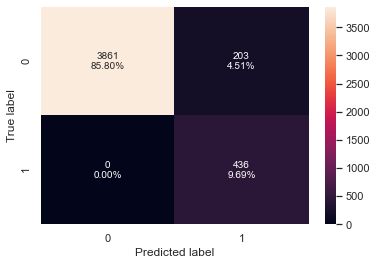

```python
confusion_matrix_sklearn(best_model2, X_train, y_train)
```

```python
# Generating performance metrics for training data for decision tree with cost complexity pruning
decision_tree_postprune_perf_train = model_performance_classification_sklearn1(
    best_model2, X_train, y_train
)
print("Training performance:")
decision_tree_postprune_perf_train
```

```
Training performance:
```

|  | Accuracy | Recall | Precision | F1 |
| --- | --- | --- | --- | --- |
| 0 | 0.954889 | 1.0 | 0.682316 | 0.811163 |

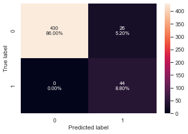

```python
confusion_matrix_sklearn(best_model2, X_test, y_test)
```

```python
# Generating performance metrics for training data for decision tree with cost complexity pruning
decision_tree_postprune_perf_test = model_performance_classification_sklearn1(
    best_model2, X_test, y_test
)
print("Testing performance:")
decision_tree_postprune_perf_test
```

```
Testing performance:
```

|  | Accuracy | Recall | Precision | F1 |
| --- | --- | --- | --- | --- |
| 0 | 0.948 | 1.0 | 0.628571 | 0.77193 |

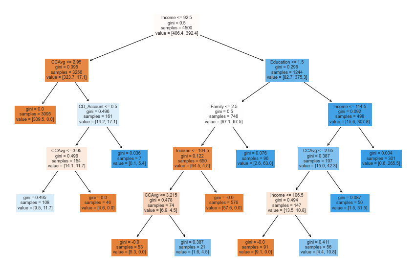

```python
plt.figure(figsize=(15, 10))

out = tree.plot_tree(
    best_model2,
    feature_names=feature_names,
    filled=True,
    fontsize=9,
    node_ids=False,
    class_names=None,
)
for o in out:
    arrow = o.arrow_patch
    if arrow is not None:
        arrow.set_edgecolor("black")
        arrow.set_linewidth(1)
plt.show()
```

```python
# Text report showing the rules of a decision tree -

print(tree.export_text(best_model2, feature_names=feature_names, show_weights=True))
```

```
|--- Income <= 92.50
|   |--- CCAvg <= 2.95
|   |   |--- weights: [309.50, 0.00] class: 0
|   |--- CCAvg >  2.95
|   |   |--- CD_Account <= 0.50
|   |   |   |--- CCAvg <= 3.95
|   |   |   |   |--- weights: [9.50, 11.70] class: 1
|   |   |   |--- CCAvg >  3.95
|   |   |   |   |--- weights: [4.60, 0.00] class: 0
|   |   |--- CD_Account >  0.50
|   |   |   |--- weights: [0.10, 5.40] class: 1
|--- Income >  92.50
|   |--- Education <= 1.50
|   |   |--- Family <= 2.50
|   |   |   |--- Income <= 104.50
|   |   |   |   |--- CCAvg <= 3.21
|   |   |   |   |   |--- weights: [5.30, 0.00] class: 0
|   |   |   |   |--- CCAvg >  3.21
|   |   |   |   |   |--- weights: [1.60, 4.50] class: 1
|   |   |   |--- Income >  104.50
|   |   |   |   |--- weights: [57.60, 0.00] class: 0
|   |   |--- Family >  2.50
|   |   |   |--- weights: [2.60, 63.00] class: 1
|   |--- Education >  1.50
|   |   |--- Income <= 114.50
|   |   |   |--- CCAvg <= 2.95
|   |   |   |   |--- Income <= 106.50
|   |   |   |   |   |--- weights: [9.10, 0.00] class: 0
|   |   |   |   |--- Income >  106.50
|   |   |   |   |   |--- weights: [4.40, 10.80] class: 1
|   |   |   |--- CCAvg >  2.95
|   |   |   |   |--- weights: [1.50, 31.50] class: 1
|   |   |--- Income >  114.50
|   |   |   |--- weights: [0.60, 265.50] class: 1
```

```python
#Important features for the decision tree

print(
    pd.DataFrame(
        best_model2.feature_importances_, columns=["Imp"], index=X_train.columns
    ).sort_values(by="Imp", ascending=False)
)
```

```
                                    Imp
Income                         0.664075
Family                         0.145291
Education                      0.103901
CCAvg                          0.079909
CD_Account                     0.006823
Age                            0.000000
County_Santa Clara County      0.000000
County_San Benito County       0.000000
County_San Bernardino County   0.000000
County_San Diego County        0.000000
County_San Francisco County    0.000000
County_San Joaquin County      0.000000
County_San Luis Obispo County  0.000000
County_San Mateo County        0.000000
County_Santa Barbara County    0.000000
County_Siskiyou County         0.000000
County_Santa Cruz County       0.000000
County_Shasta County           0.000000
County_Riverside County        0.000000
County_Solano County           0.000000
County_Sonoma County           0.000000
County_Stanislaus County       0.000000
County_Trinity County          0.000000
County_Tuolumne County         0.000000
County_Ventura County          0.000000
County_Sacramento County       0.000000
County_Napa County             0.000000
County_Placer County           0.000000
County_Humboldt County         0.000000
Mortgage                       0.000000
Securities_Account             0.000000
Online                         0.000000
CreditCard                     0.000000
County_Butte County            0.000000
County_Contra Costa County     0.000000
County_El Dorado County        0.000000
County_Fresno County           0.000000
County_Imperial County         0.000000
County_Orange County           0.000000
County_Kern County             0.000000
County_Lake County             0.000000
County_Los Angeles County      0.000000
County_Marin County            0.000000
County_Mendocino County        0.000000
County_Merced County           0.000000
County_Monterey County         0.000000
Experience                     0.000000
County_Yolo County             0.000000
```

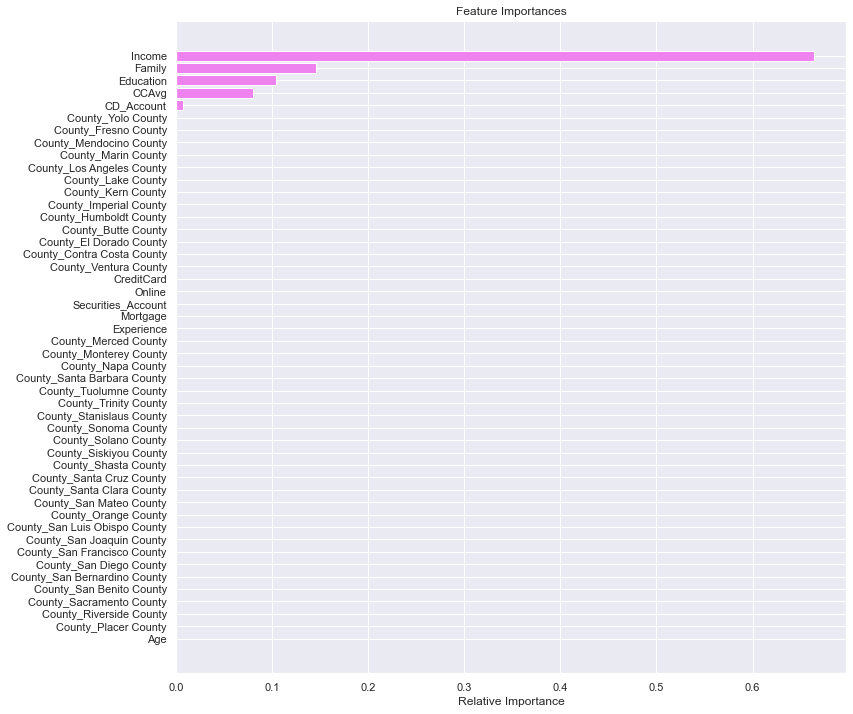

```python
importances = best_model2.feature_importances_
indices = np.argsort(importances)

plt.figure(figsize=(12, 12))
plt.title("Feature Importances")
plt.barh(range(len(indices)), importances[indices], color="violet", align="center")
plt.yticks(range(len(indices)), [feature_names[i] for i in indices])
plt.xlabel("Relative Importance")
plt.show()
```

```python
# Training set comparison
models_train_comp_df1 = pd.concat(
    [
        decision_tree_perf_train,
        decision_tree_tune_perf_train,
        decision_tree_postprune_perf_train,
    ],
    axis=0,
)
models_train_comp_df1.columns = [
    "Accuracy",
    "Recall",
    "Precision",
    "F1",
]
print("Training set performance comparison:")
models_train_comp_df1
```

```
Training set performance comparison:
```

|  | Accuracy | Recall | Precision | F1 |
| --- | --- | --- | --- | --- |
| 0 | 1.000000 | 1.000000 | 1.000000 | 1.000000 |
| 0 | 0.926889 | 0.988532 | 0.570861 | 0.723762 |
| 0 | 0.954889 | 1.000000 | 0.682316 | 0.811163 |

```python
# Testing set comparison
models_test_comp_df1 = pd.concat(
    [
        decision_tree_perf_test,
        decision_tree_tune_perf_test,
        decision_tree_postprune_perf_test,
    ],
    axis=0,
)
models_test_comp_df1.columns = [
    "Accuracy",
    "Recall",
    "Precision",
    "F1",
]
print("Testing set performance comparison:")
models_test_comp_df1
```

```
Testing set performance comparison:
```

|  | Accuracy | Recall | Precision | F1 |
| --- | --- | --- | --- | --- |
| 0 | 0.990 | 0.886364 | 1.000000 | 0.939759 |
| 0 | 0.942 | 0.977273 | 0.605634 | 0.747826 |
| 0 | 0.948 | 1.000000 | 0.628571 | 0.771930 |

#### Observation

The best model to pick would be the first decision tree model (default depth) based on its testing performance (Recall = 88% and F1 = 93.9%). If we were to use only a recall score (we are interested in as high a true positivity rate as possible), then the best model would be the post pruned tree model with a recall of 100% and an F1 score of 77.1%. However, this model even though it had a high recall score, it would not prevent the occurance of false positives (the recall formula has false negatives in the denominator). As false positives will more costly to the bank in terms of resources, time (spending time and money in targeting a customer who does not take a loan), it is appropriate to pick the decision tree with the default depth.

#### Misclassfication analysis

Note: We want to see the difference between the predicted values (from best decision tree model) and the original Personal_Value column data. Towards this end, we shall compare the unique value counts for the predicted data and the original personal loan column.

```python
# Copying the original processed dataframe
loanDatamis = loanDataprep.copy()
loanDatamisclass3 = loanDataprep.copy()
```

```python
# Replacing the Personal_Value column by the predicted values
loanDatamisclass3["prediction"] = model.predict(
    loanDatamisclass3.drop(["Personal_Loan"], axis=1)
)
```

```python
# Original column unique values
loanDatamis["Personal_Loan"].value_counts()
```

```
0    4520
1     480
Name: Personal_Loan, dtype: int64
```

```python
# Predicted column unique values
loanDatamisclass3["prediction"].value_counts()
```

```
0    4525
1     475
Name: prediction, dtype: int64
```

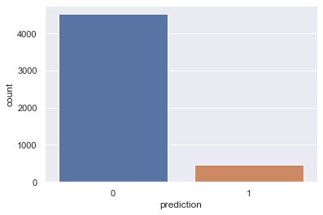

```python
# Countplot of the predicted data for the personal loan column
sns.countplot(
    data=loanDatamisclass3,
    x=loanDatamisclass3["prediction"],
)
```

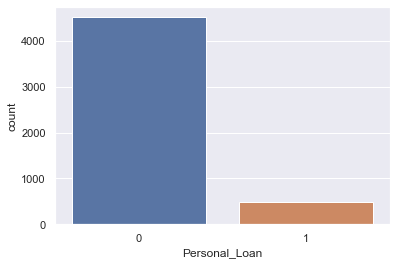

```python
# Countplot of the original Personal Loan column from the data
sns.countplot(
    data=loanDatamis,
    x=loanDatamis["Personal_Loan"],
)
```

#### Observation

A comparison of the predicted and original Personal_Loan column data shows (a) the decision tree model predicted that less number of customers would take a personal loan as compared to the number of customers who took a loan last year. This is visible as a slight difference in the countplots as well for the '1' category.

This shows that the model has a small number of false negatives (a count of 5).

The model that was used to fit for misclassification analysis had the following performance metrics: 88.6% recall, 100% precision, 93.9% F1 score.

Overall, we can conclude that the decision tree model is a reasonable classification model and it helped to reduce the number of false positives, which would have been more costly to the bank if they actually occured.

### 10. Insights and Recommendations

#### Recommendations

1. In order to have a higher conversion rate of liability customers to asset customers, the bank should develop a personal loan product that can appeal to the 75% of customers who earn less than 100,000 dollars per year.
2. Income is one of the good predictors of whether the customer will take a personal loan or not, so the marketing campaign should continue to target high income earners with products that were similar to what was offered last year.
3. The models showed that family is also an important factor - the more the number of people in the household, larger their annunal income, and more likely that they would be taking a personal loan. Based on this, the marketing department should target multiple products that can appeal to multiple people household - college loans as an example.